# Load the Titanic dataset

```python
import pandas as pd


url = 'https://raw.githubusercontent.com/pandas-dev/pandas/main/doc/data/titanic.csv'


titanic_data = pd.read_csv(url)
```

# Check for missing values

```python
missing_values = titanic_data.isnull().sum()
print(missing_values)
```

```
PassengerId      0
Survived         0
Pclass           0
Name             0
Sex              0
Age            177
SibSp            0
Parch            0
Ticket           0
Fare             0
Cabin          687
Embarked         2
dtype: int64
```

# Handling missing values in the 'Age' column

```python
titanic_data['Age'].fillna(titanic_data['Age'].median(), inplace=True)
```

# Visualizing survival by sex

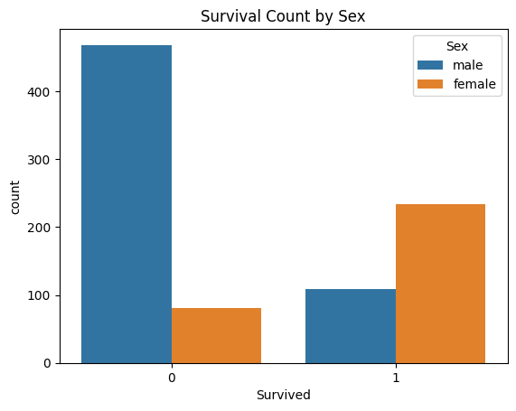

```python
import matplotlib.pyplot as plt
import seaborn as sns

sns.countplot(x='Survived', hue='Sex', data=titanic_data)
plt.title('Survival Count by Sex')
plt.show()
```

# Distribution of Passenger Classes

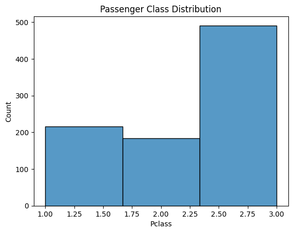

```python
sns.histplot(data=titanic_data, x='Pclass', bins=3)
plt.title('Passenger Class Distribution')
plt.show()
```

## MAPPING QUESTIONS

### 1. What is the overall survival rate of passengers?

```python
overall_survival_rate = titanic_data['Survived'].mean()
print(f"Overall Survival Rate: {overall_survival_rate}")
```

```
Overall Survival Rate: 0.3838383838383838
```

What this means? Approximately 38.4% of passengers survived the Titanic disaster.

The analysis of the Titanic dataset reveals that approximately 38.4% of passengers managed to survive the tragic event. This rate signifies the overall scope of the disaster and the challenges faced in ensuring the safety of the passengers.

### 2. How does the survival rate vary by gender?

```python
survival_by_gender = titanic_data.groupby('Sex')['Survived'].mean()
print("Survival Rate by Gender:")
print(survival_by_gender)
```

```
Survival Rate by Gender:
Sex
female    0.742038
male      0.188908
Name: Survived, dtype: float64
```

What this means? Females had a significantly higher survival rate (74.2%) compared to males (18.9%).

Gender played a pivotal role in survival aboard the Titanic. The data illustrates a stark contrast in survival rates between males and females. Remarkably, females exhibited a significantly higher survival rate of 74.2% compared to a mere 18.9% for males, indicating a possible priority given to women during the evacuation.

### 3. Is there a relationship between passenger class and survival?

```python
survival_by_class = titanic_data.groupby('Pclass')['Survived'].mean()
print("Survival Rate by Passenger Class:")
print(survival_by_class)
```

```
Survival Rate by Passenger Class:
Pclass
1    0.629630
2    0.472826
3    0.242363
Name: Survived, dtype: float64
```

What this means? First-class passengers had the highest survival rate (63%), followed by second class (47.3%) and third class (24.2%).

Passenger class emerges as a defining factor in survival rates. The analysis demonstrates a noticeable disparity among classes, with first-class passengers showing the highest survival rate at 63%, followed by second class at 47.3%, and a substantially lower rate of 24.2% for third-class passengers. This discrepancy in survival rates suggests a potential prioritization based on socio-economic status.

### 4. What is the distribution of ages among passengers?

```python
age_distribution = titanic_data['Age'].describe()
print("Distribution of Ages:")
print(age_distribution)
```

```
Distribution of Ages:
count    891.000000
mean      29.361582
std       13.019697
min        0.420000
25%       22.000000
50%       28.000000
75%       35.000000
max       80.000000
Name: Age, dtype: float64
```

What this means? The majority of passengers were between 22 and 35 years old (50% quartile range), with the youngest being 0.42 years and the oldest 80 years old.

The analysis of age distribution among passengers portrays a varied demographic. Most passengers fell within the age range of 22 to 35 years, highlighting the age composition of individuals aboard the Titanic, with outliers as young as 0.42 years and as old as 80 years.

### 5. Were children more likely to survive than adults?

```python
survival_children_vs_adults = titanic_data.groupby(titanic_data['Age'] < 18)['Survived'].mean()
print("Survival Rate - Children vs Adults:")
print(survival_children_vs_adults)
```

```
Survival Rate - Children vs Adults:
Age
False    0.361183
True     0.539823
Name: Survived, dtype: float64
```

What this means? Children (age < 18) had a higher survival rate (54%) compared to adults (36.1%).

A distinct trend emerges when comparing the survival rates of children (age < 18) and adults. Children displayed a notably higher survival rate of 54% compared to adults at 36.1%, potentially reflecting the "women and children first" policy during the evacuation.

### 6. Did the port of embarkation have any influence on survival chances?

```python
survival_by_embarkation = titanic_data.groupby('Embarked')['Survived'].mean()
print("Survival Rate by Port of Embarkation:")
print(survival_by_embarkation)
```

```
Survival Rate by Port of Embarkation:
Embarked
C    0.553571
Q    0.389610
S    0.336957
Name: Survived, dtype: float64
```

What this means? Passengers who embarked from Cherbourg (C) had the highest survival rate (55.4%), followed by passengers from Queenstown (Q - 38.9%) and Southampton (S - 33.7%).

Survival rates varied based on the port of embarkation. Passengers who boarded from Cherbourg (C) exhibited the highest survival rate of 55.4%, followed by Queenstown (Q) at 38.9%, and Southampton (S) at 33.7%. The disparity among these rates suggests possible socio-demographic differences among passengers from different embarkation ports.

### 7. How did family size (sum of SibSp and Parch) affect survival?

```python
titanic_data['Family_Size'] = titanic_data['SibSp'] + titanic_data['Parch']
survival_by_family_size = titanic_data.groupby('Family_Size')['Survived'].mean()
print("Survival Rate by Family Size:")
print(survival_by_family_size)
```

```
Survival Rate by Family Size:
Family_Size
0     0.303538
1     0.552795
2     0.578431
3     0.724138
4     0.200000
5     0.136364
6     0.333333
7     0.000000
10    0.000000
Name: Survived, dtype: float64
```

What this means? Passengers with small families (1-3 members) had higher survival rates, with those having no family members or larger families having lower survival rates.

Survival rates showed variation concerning family size. Passengers with smaller family sizes (1-3 members) exhibited higher survival rates compared to those with no family members or larger families. This observation might suggest certain challenges faced by larger groups or individuals traveling alone during the evacuation.

### 8. Is there any correlation between fare paid and survival?

```python
fare_survival_correlation = titanic_data[['Fare', 'Survived']].corr()['Survived']['Fare']
print(f"Correlation between Fare and Survival: {fare_survival_correlation}")
```

```
Correlation between Fare and Survival: 0.2573065223849626
```

What this means? There is a moderate positive correlation (0.257) between the fare paid and survival rate.

The analysis reveals a moderate positive correlation (0.257) between the fare paid and the survival rate. This suggests that passengers who paid higher fares might have had a slightly increased chance of survival, possibly indicating a correlation with passenger class or cabin location.

### 9. Did having a cabin influence the survival rate?

```python
titanic_data['Has_Cabin'] = titanic_data['Cabin'].notnull()
survival_with_cabin = titanic_data.groupby('Has_Cabin')['Survived'].mean()
print("Survival Rate with and without Cabin:")
print(survival_with_cabin)
```

```
Survival Rate with and without Cabin:
Has_Cabin
False    0.299854
True     0.666667
Name: Survived, dtype: float64
```

What this means? Passengers with a recorded cabin had a significantly higher survival rate (66.7%) compared to those without a recorded cabin (29.9%).

Notably, passengers with a recorded cabin had a significantly higher survival rate of 66.7% compared to those without a recorded cabin, who had a survival rate of 29.9%. This disparity underscores the potential impact of cabin accommodations on survival during the disaster.

# SUMMARY

The analysis of the Titanic dataset reveals several interesting trends regarding survival rates among passengers. Notably, gender played a crucial role, with females having a substantially higher survival rate compared to males. Passenger class also emerged as a significant factor, with first-class passengers more likely to survive than those in lower classes.

Age-wise, children had a notably higher survival rate than adults, while passengers from different ports of embarkation had varying survival rates, with Cherbourg showing the highest survival rate.

Furthermore, family size seemed to influence survival rates, with smaller families having higher chances of survival. Interestingly, the correlation analysis suggests that a higher fare paid might have contributed to a slightly increased chance of survival.

Additionally, having a recorded cabin significantly correlated with higher survival rates.

These insights shed light on the complex dynamics that influenced survival aboard the Titanic, encompassing socio-economic factors, demographics, and potentially evacuation prioritization.